# Análisis Factorial Confirmatorio (reducido ola 3)

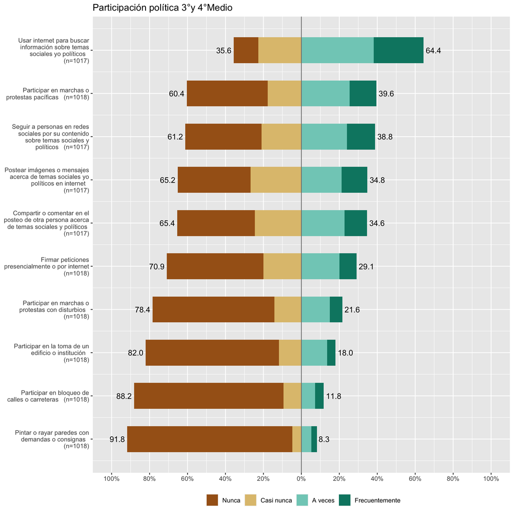

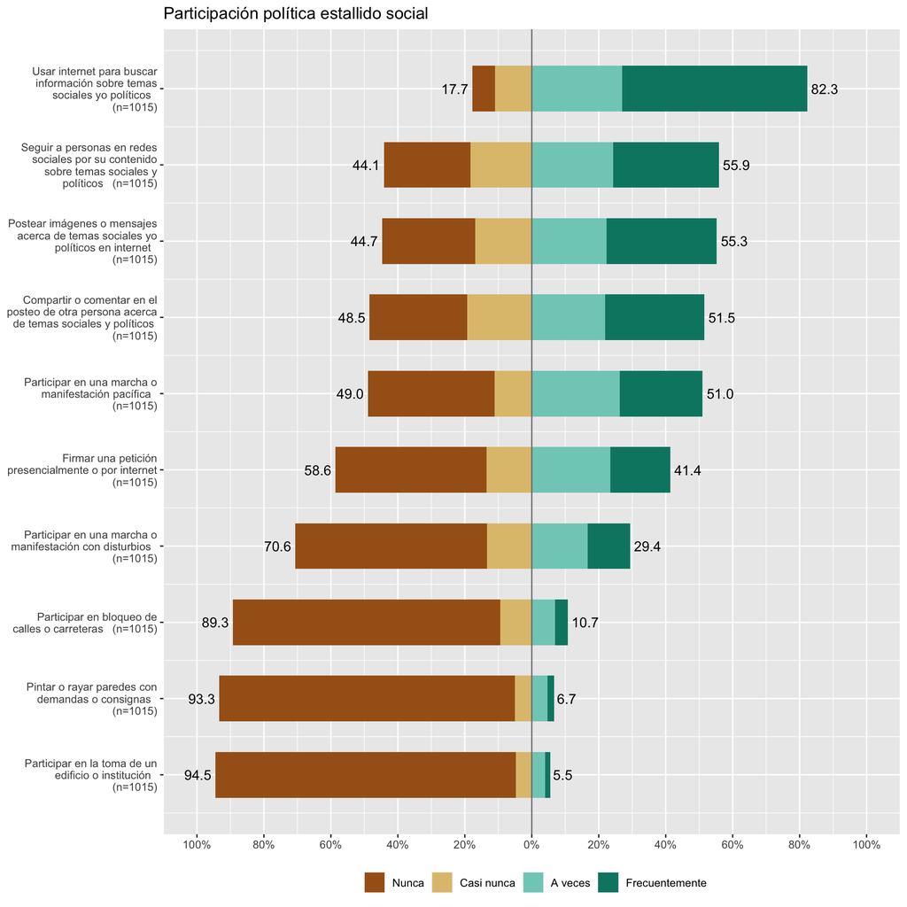

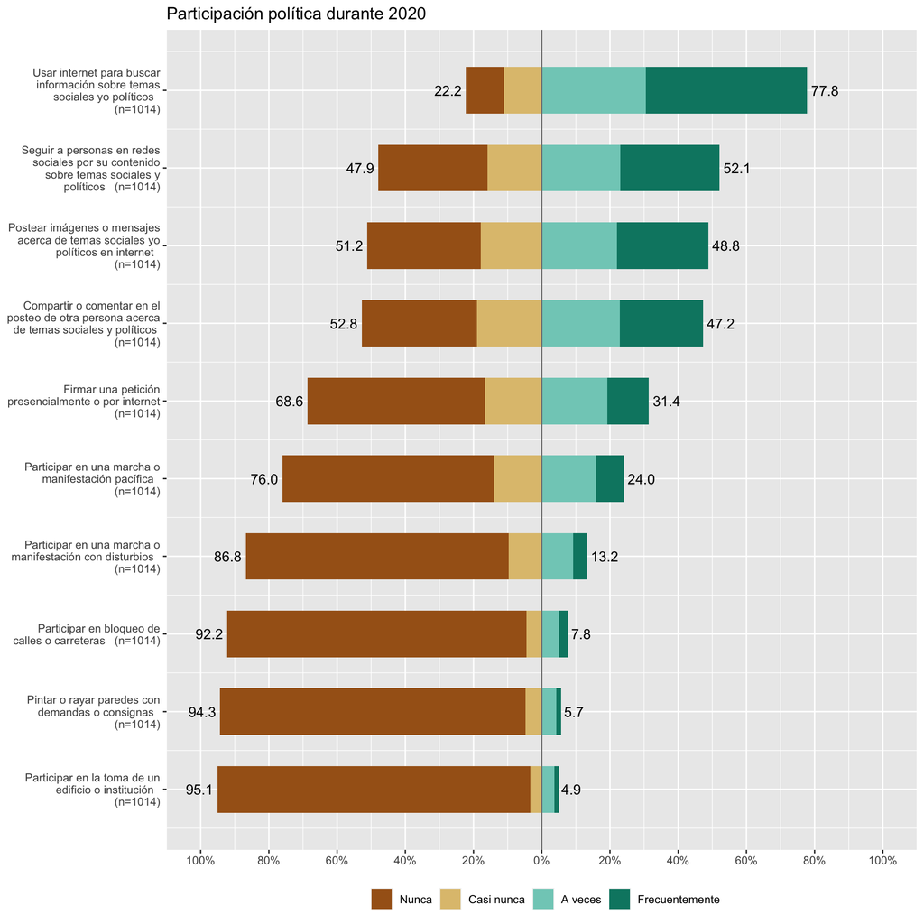

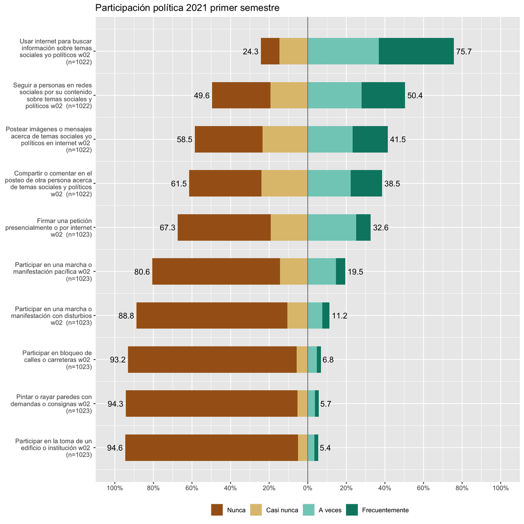

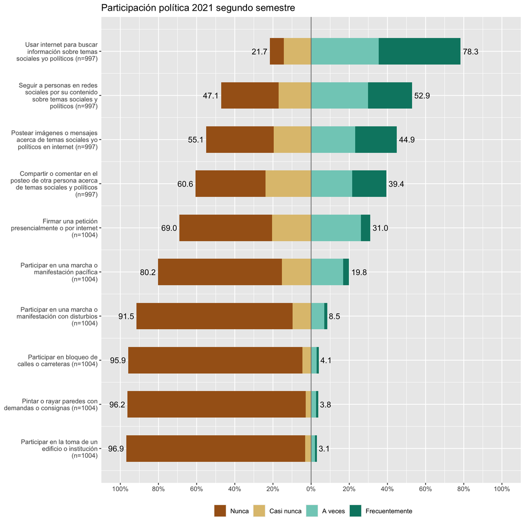

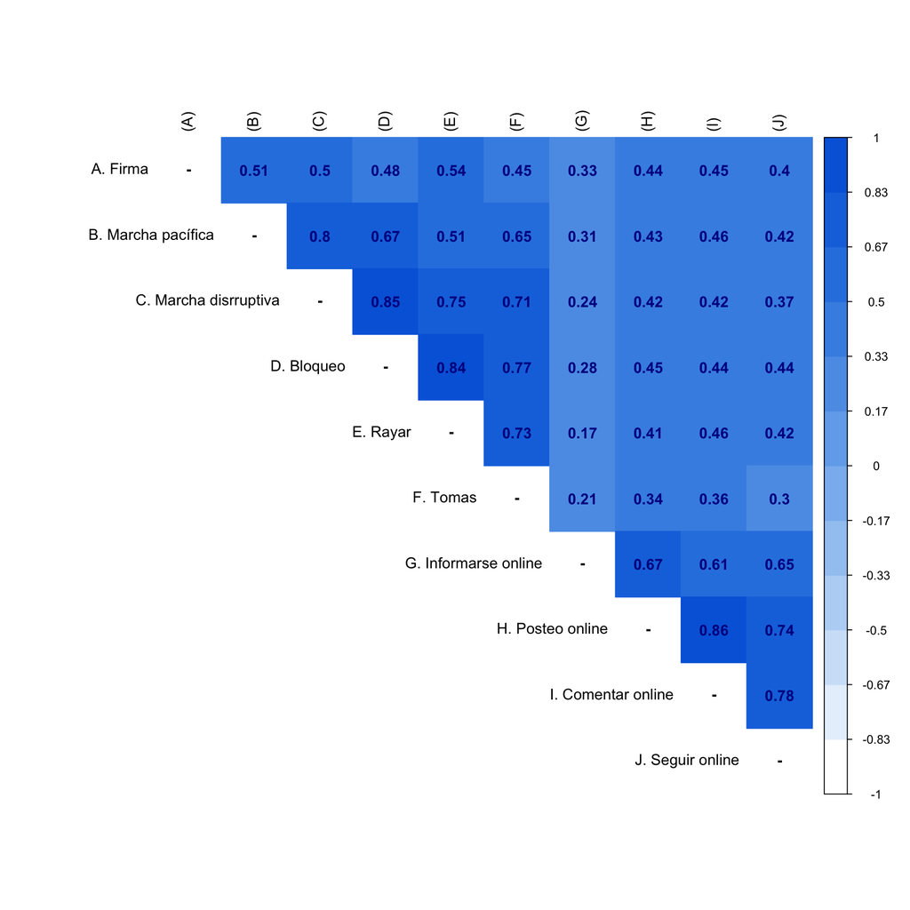

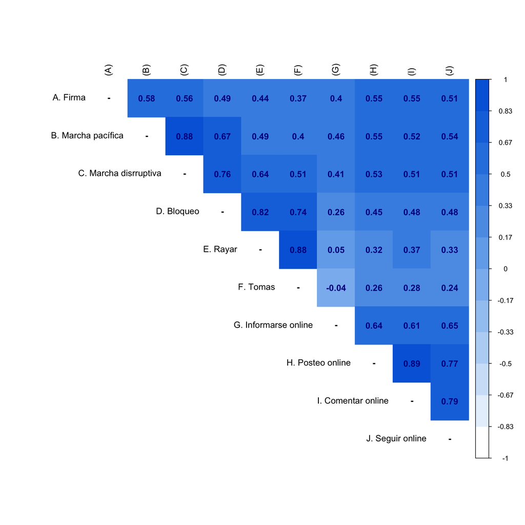

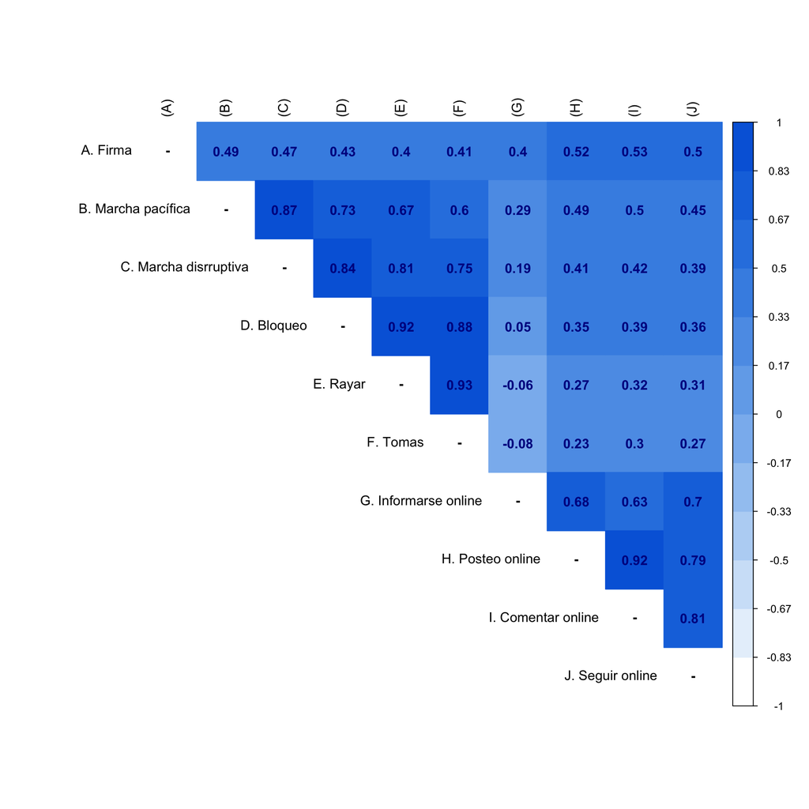

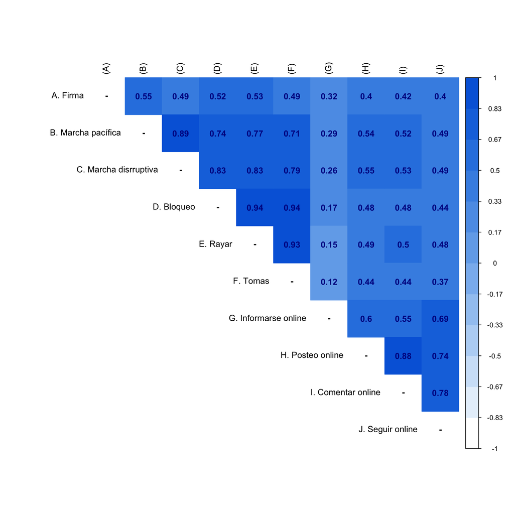

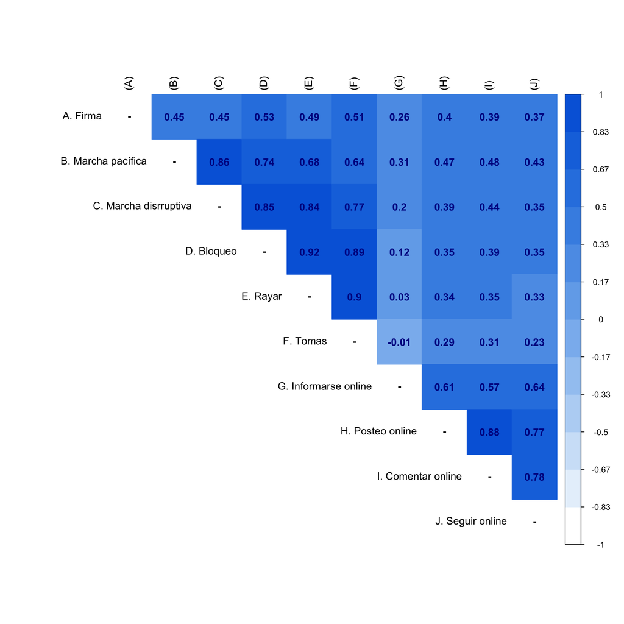

En las Figuras se muestran las correlaciones policóricas de los indicadores para cada una de las tres variables latentes: participación disruptiva, participación no disruptiva y participación online. Durante los 5 momentos analizados: 3º y 4º medio, estallido social, durante 2020, primer semestre 2021 y segundo semestre 2021, los datos indican altas correlaciones para los items de las variables de participación disruptiva, es decir, los indicadores de “marcha disruptiva”, “bloqueo”, “rayar” y “tomas”, de igual forma se da en los indicadores de participación online, es decir, “informarse online”, “posteo online”, “comentar online” y “seguir online”. Lo que difiere con participación no disruptiva, correspondiente a los ítems de “firma” y “marcha pacífica”, los que correlacionaron en todos los tiempos con un indice menor, siendo el mas alto r = .58, encontrando incluso correlaciones mas altas de estas con indicadores de otras variables latentes, como es el caso de marcha pacífica con marcha disruptiva ( r = .8, p < 0.1) durante 3º y 4º medio.

Siguiendo los criterios convencionales para evaluar la bondad de ajuste del modelo de medición, se muestra que el modelo tridimensional no posee un ajuste aceptable para los momentos de Estallido Social (χ2(gl) = 952.01(32), CFI = .99, TLI = .99, RMSEA = .10), durante el 2020 (χ2(gl) = 920.71(32), CFI = .99, TLI = .99, RMSEA = .10) y durante el primer semestre de 2021 (χ2(gl) = 359.77(32), CFI = 1, TLI = .99, RMSEA = .08), en cuanto al indicador de parsimonia RMSEA; mientras que durante 3° y 4° medio (χ2(gl) = 372.15(32), CFI = 1, TLI = .99, RMSEA = .06) y el segundo semestre de 2021 (χ2(gl) = 131.32(32), CFI = 1, TLI = 1, RMSEA = .05), los indicadores son aceptables. Asimismo, en los modelos bidimensionales de Estallido social (χ2(gl) = 452.15(19), CFI = .99, TLI = .99, RMSEA = .09), durante el 2020 (χ2(gl) = 352.43(19), CFI = 1, TLI = 1, RMSEA = .08) y durante el primer semestre de 2021 (χ2(gl) = 161.42(19), CFI = 1, TLI = 1, RMSEA = .07), siguen sin poseer un ajuste deseable en el indicador de parsimonia RMSEA, no obstante se presenta una mejora en todos los indicadores, al igual que durante 3° y 4° medio (χ2(gl) = 103.18(19), CFI = 1, TLI = 1, RMSEA = .04) y durante el segundo semestre de 2021 (χ2(gl) = 47.14(19), CFI = 1, TLI = 1, RMSEA = .04). Si bien estos indicadores ya eran considerados aceptables en estos dos modelos, con un modelo bidimensional mejoraron. Por esta razón se decidió utilizar el modelo bidimensional y descartar los ítems de activisimo no disrruptivo.

###invarianza

### Modelo de medición: invarianza longitudinal configural

```r
# Especificación del modelo
afc_invar_conf <- '
## 3° y 4°
act_disrup_w1 =~ part_pol_marcha_dis_w01 + part_pol_bloqueo_w01 + part_pol_rayar_w01 + part_pol_toma_w01
act_online_w1 =~ part_pol_online_w01 + part_online_post_w01 + part_online_com_w01 + part_online_seg_w01

## Estallido
act_disrup_w2 =~ part_pol_marc_dis_21_w01 + part_pol_bloq_21_w01 + part_pol_rayar_21_w01 + part_pol_toma_21_w01
act_online_w2 =~ part_pol_online_info_21_w01 + part_pol_online_post_21_w01 + part_pol_online_com_21_w01 + part_pol_online_seg_21_w01

## 2020
act_disrup_w3 =~ part_pol_marc_dis_20_w01 + part_pol_bloq_20_w01 + part_pol_rayar_20_w01 + part_pol_toma_20_w01
act_online_w3 =~ part_pol_online_info_20_w01 + part_pol_online_post_20_w01 + part_pol_online_com_20_w01 + part_pol_online_seg_20_w01

## 2021 primer semestre
act_disrup_w4 =~ part_pol_marc_dis_w02 + part_pol_bloq_w02 + part_pol_rayar_w02 + part_pol_toma_w02
act_online_w4 =~ part_pol_online_info_w02 + part_pol_online_post_w02 + part_pol_online_com_w02 + part_pol_online_seg_w02

## 2021 segundo semestre
act_disrup_w5 =~ part_pol_marc_dis_21b_w03 + part_pol_bloq_21b_w03 + part_pol_rayar_21b_w03 + part_pol_toma_21b_w03
act_online_w5 =~ part_pol_online_info_21b_w03 + part_pol_online_post_21b_w03 + part_pol_online_com_21b_w03 + part_pol_online_seg_21b_w03

## Covarianzas
part_pol_marcha_dis_w01 ~~ part_pol_marc_dis_21_w01

part_pol_bloqueo_w01 ~~ part_pol_bloq_21_w01

part_pol_rayar_w01 ~~ part_pol_rayar_21_w01

part_pol_toma_w01 ~~ part_pol_toma_21_w01

part_pol_online_w01 ~~ part_pol_online_info_21_w01

part_online_post_w01 ~~ part_pol_online_post_21_w01

part_online_com_w01 ~~ part_pol_online_com_21_w01

part_online_seg_w01 ~~ part_pol_online_seg_21_w01


part_pol_marc_dis_21_w01 ~~ part_pol_marc_dis_20_w01

part_pol_bloq_21_w01 ~~ part_pol_bloq_20_w01

part_pol_rayar_21_w01 ~~ part_pol_rayar_20_w01

part_pol_toma_21_w01 ~~ part_pol_toma_20_w01

part_pol_online_info_21_w01 ~~ part_pol_online_info_20_w01

part_pol_online_post_21_w01 ~~ part_pol_online_post_20_w01

part_pol_online_com_21_w01 ~~ part_pol_online_com_20_w01

part_pol_online_seg_21_w01 ~~ part_pol_online_seg_20_w01


part_pol_marc_dis_20_w01 ~~ part_pol_marc_dis_w02

part_pol_bloq_20_w01 ~~ part_pol_bloq_w02

part_pol_rayar_20_w01 ~~ part_pol_rayar_w02

part_pol_toma_20_w01 ~~ part_pol_toma_w02

part_pol_online_info_20_w01 ~~ part_pol_online_info_w02

part_pol_online_post_20_w01 ~~ part_pol_online_post_w02

part_pol_online_com_20_w01 ~~ part_pol_online_com_w02

part_pol_online_seg_20_w01 ~~ part_pol_online_seg_w02


part_pol_marc_dis_w02 ~~ part_pol_marc_dis_21b_w03

part_pol_bloq_w02 ~~ part_pol_bloq_21b_w03

part_pol_rayar_w02 ~~ part_pol_rayar_21b_w03

part_pol_toma_w02 ~~ part_pol_toma_21b_w03

part_pol_online_info_w02 ~~ part_pol_online_info_21b_w03

part_pol_online_post_w02 ~~ part_pol_online_post_21b_w03

part_pol_online_com_w02 ~~ part_pol_online_com_21b_w03
part_pol_online_seg_w02 ~~ part_pol_online_seg_21b_w03

'

# Estimación del modelo
fit_invar_conf <- lavaan::cfa(afc_invar_conf, data = df_wide, ordered = T,
                     std.lv = TRUE , #factor loadings standarized
                     )
 lavaan::summary(fit_invar_conf, fit.measures = T, standardized = T)
```

lavaan 0.6-11 ended normally after 75 iterations

Estimator DWLS Optimization method NLMINB Number of model parameters 237

```
                                              Used       Total
```

Number of observations 976 1029

Model Test User Model: Standard Robust Test Statistic 2723.398 2783.580 Degrees of freedom 663 663 P-value (Chi-square) 0.000 0.000 Scaling correction factor 1.139 Shift parameter 392.527 simple second-order correction

Model Test Baseline Model:

Test statistic 309325.111 72373.971 Degrees of freedom 780 780 P-value 0.000 0.000 Scaling correction factor 4.310

User Model versus Baseline Model:

Comparative Fit Index (CFI) 0.993 0.970 Tucker-Lewis Index (TLI) 0.992 0.965

Robust Comparative Fit Index (CFI) NA Robust Tucker-Lewis Index (TLI) NA

Root Mean Square Error of Approximation:

RMSEA 0.056 0.057 90 Percent confidence interval - lower 0.054 0.055 90 Percent confidence interval - upper 0.059 0.059 P-value RMSEA <= 0.05 0.000 0.000

Robust RMSEA NA 90 Percent confidence interval - lower NA 90 Percent confidence interval - upper NA

Standardized Root Mean Square Residual:

SRMR 0.083 0.083

Parameter Estimates:

Standard errors Robust.sem Information Expected Information saturated (h1) model Unstructured

Latent Variables: Estimate Std.Err z-value P(>|z|) Std.lv Std.all act_disrup_w1 =~  
prt_pl_mrc__01 0.888 0.018 50.100 0.000 0.888 0.888 prt_pl_blq_w01 0.944 0.015 63.075 0.000 0.944 0.944 prt_pl_ryr_w01 0.914 0.023 40.260 0.000 0.914 0.914 part_pl_tm_w01 0.772 0.026 30.053 0.000 0.772 0.772 act_online_w1 =~  
prt_pl_nln_w01 0.666 0.025 27.034 0.000 0.666 0.666 prt_nln_pst_01 0.912 0.011 81.983 0.000 0.912 0.912 prt_nln_cm_w01 0.935 0.011 85.212 0.000 0.935 0.935 prt_nln_sg_w01 0.859 0.015 59.156 0.000 0.859 0.859 act_disrup_w2 =~  
prt_pl___21_01 0.813 0.025 33.131 0.000 0.813 0.813 prt_pl_b_21_01 0.909 0.016 56.501 0.000 0.909 0.909 prt_pl_r_21_01 0.930 0.016 59.199 0.000 0.930 0.930 prt_pl_t_21_01 0.878 0.021 41.080 0.000 0.878 0.878 act_online_w2 =~  
prt_pl___21_01 0.673 0.024 27.648 0.000 0.673 0.673 prt_pl___21_01 0.927 0.009 104.826 0.000 0.927 0.927 prt_pl___21_01 0.934 0.008 113.582 0.000 0.934 0.934 prt_pl___21_01 0.879 0.012 73.347 0.000 0.879 0.879 act_disrup_w3 =~  
prt_pl___20_01 0.878 0.020 43.243 0.000 0.878 0.878 prt_pl_b_20_01 0.949 0.011 85.928 0.000 0.949 0.949 prt_pl_r_20_01 0.974 0.008 118.527 0.000 0.974 0.974 prt_pl_t_20_01 0.930 0.014 66.898 0.000 0.930 0.930 act_online_w3 =~  
prt_pl___20_01 0.710 0.021 33.092 0.000 0.710 0.710 prt_pl___20_01 0.951 0.007 134.146 0.000 0.951 0.951 prt_pl___20_01 0.951 0.007 135.712 0.000 0.951 0.951 prt_pl___20_01 0.879 0.012 74.078 0.000 0.879 0.879 act_disrup_w4 =~  
prt_pl_mrc__02 0.905 0.021 42.504 0.000 0.905 0.905 prt_pl_blq_w02 0.984 0.006 161.001 0.000 0.984 0.984 prt_pl_ryr_w02 0.966 0.008 114.774 0.000 0.966 0.966 part_pl_tm_w02 0.936 0.012 76.568 0.000 0.936 0.936 act_online_w4 =~  
prt_pl_nln__02 0.658 0.025 26.816 0.000 0.658 0.658 prt_pl_nln__02 0.941 0.009 101.941 0.000 0.941 0.941 prt_pl_nln__02 0.924 0.010 91.317 0.000 0.924 0.924 prt_pl_nln02 0.862 0.013 65.955 0.000 0.862 0.862 act_disrup_w5 =~  
prt_pl_21_03 0.913 0.022 41.653 0.000 0.913 0.913 prt_pl_b_21_03 0.966 0.015 64.744 0.000 0.966 0.966 prt_pl_r_21_03 0.964 0.015 63.325 0.000 0.964 0.964 prt_pl_t_21_03 0.889 0.022 40.294 0.000 0.889 0.889 act_online_w5 =~  
prt_pl___21_03 0.688 0.025 27.468 0.000 0.688 0.688 prt_pl___21_03 0.927 0.009 101.237 0.000 0.927 0.927 prt_pl___21_03 0.926 0.010 97.111 0.000 0.926 0.926 prt_pl___21_03 0.876 0.013 67.964 0.000 0.876 0.876

Covariances: Estimate Std.Err z-value P(>|z|) Std.lv .part_pol_marcha_dis_w01 ~~  
.prt_pl_21_01 0.058 0.028 2.088 0.037 0.058 .part_pol_bloqueo_w01 ~~  
.prt_pl_b_21_01 0.095 0.020 4.635 0.000 0.095 .part_pol_rayar_w01 ~~  
.prt_pl_r_21_01 0.161 0.024 6.638 0.000 0.161 .part_pol_toma_w01 ~~  
.prt_pl_t_21_01 0.003 0.038 0.079 0.937 0.003 .part_pol_online_w01 ~~  
.prt_pl_21_01 0.223 0.025 8.955 0.000 0.223 .part_online_post_w01 ~~  
.prt_pl_21_01 0.084 0.015 5.507 0.000 0.084 .part_online_com_w01 ~~  
.prt_pl_21_01 0.073 0.016 4.628 0.000 0.073 .part_online_seg_w01 ~~  
.prt_pl_21_01 0.172 0.019 9.262 0.000 0.172 .part_pol_marc_dis_21_w01 ~~  
.prt_pl_20_01 0.121 0.030 4.087 0.000 0.121 .part_pol_bloq_21_w01 ~~  
.prt_pl_b_20_01 0.018 0.019 0.951 0.342 0.018 .part_pol_rayar_21_w01 ~~  
.prt_pl_r_20_01 0.075 0.019 3.975 0.000 0.075 .part_pol_toma_21_w01 ~~  
.prt_pl_t_20_01 0.096 0.019 4.963 0.000 0.096 .part_pol_online_info_21_w01 ~~  
.prt_pl_20_01 0.393 0.023 16.946 0.000 0.393 .part_pol_online_post_21_w01 ~~  
.prt_pl_20_01 0.073 0.011 6.497 0.000 0.073 .part_pol_online_com_21_w01 ~~  
.prt_pl_20_01 0.069 0.011 6.211 0.000 0.069 .part_pol_online_seg_21_w01 ~~  
.prt_pl_20_01 0.215 0.018 12.256 0.000 0.215 .part_pol_marc_dis_20_w01 ~~  
.prt_pl_mrc__02 0.079 0.032 2.481 0.013 0.079 .part_pol_bloq_20_w01 ~~  
.prt_pl_blq_w02 0.040 0.021 1.933 0.053 0.040 .part_pol_rayar_20_w01 ~~  
.prt_pl_ryr_w02 0.061 0.022 2.730 0.006 0.061 .part_pol_toma_20_w01 ~~  
.part_pl_tm_w02 0.101 0.027 3.674 0.000 0.101 .part_pol_online_info_20_w01 ~~  
.prt_pl_nln__02 0.272 0.022 12.383 0.000 0.272 .part_pol_online_post_20_w01 ~~  
.prt_pl_nln__02 0.059 0.011 5.423 0.000 0.059 .part_pol_online_com_20_w01 ~~  
.prt_pl_nln__02 0.022 0.012 1.752 0.080 0.022 .part_pol_online_seg_20_w01 ~~  
.prt_pl_nln__02 0.144 0.016 9.178 0.000 0.144 .part_pol_marc_dis_w02 ~~  
.prt_pl___21_03 0.092 0.036 2.551 0.011 0.092 .part_pol_bloq_w02 ~~  
.prt_pl_b_21_03 0.102 0.024 4.351 0.000 0.102 .part_pol_rayar_w02 ~~  
.prt_pl_r_21_03 0.029 0.033 0.897 0.370 0.029 .part_pol_toma_w02 ~~  
.prt_pl_t_21_03 0.089 0.040 2.203 0.028 0.089 .part_pol_online_info_w02 ~~  
.prt_pl___21_03 0.273 0.023 11.800 0.000 0.273 .part_pol_online_post_w02 ~~  
.prt_pl___21_03 0.077 0.013 5.891 0.000 0.077 .part_pol_online_com_w02 ~~  
.prt_pl___21_03 0.038 0.013 2.910 0.004 0.038 .part_pol_online_seg_w02 ~~  
.prt_pl___21_03 0.117 0.016 7.314 0.000 0.117 act_disrup_w1 ~~  
act_online_w1 0.504 0.033 15.290 0.000 0.504 act_disrup_w2 0.702 0.032 22.097 0.000 0.702 act_online_w2 0.301 0.041 7.298 0.000 0.301 act_disrup_w3 0.703 0.033 21.252 0.000 0.703 act_online_w3 0.282 0.040 6.972 0.000 0.282 act_disrup_w4 0.579 0.041 14.017 0.000 0.579 act_online_w4 0.239 0.041 5.849 0.000 0.239 act_disrup_w5 0.553 0.046 11.924 0.000 0.553 act_online_w5 0.216 0.042 5.184 0.000 0.216 act_online_w1 ~~  
act_disrup_w2 0.491 0.035 13.915 0.000 0.491 act_online_w2 0.602 0.026 23.205 0.000 0.602 act_disrup_w3 0.516 0.039 13.348 0.000 0.516 act_online_w3 0.620 0.025 24.370 0.000 0.620 act_disrup_w4 0.418 0.044 9.403 0.000 0.418 act_online_w4 0.568 0.028 20.617 0.000 0.568 act_disrup_w5 0.370 0.046 8.017 0.000 0.370 act_online_w5 0.534 0.029 18.585 0.000 0.534 act_disrup_w2 ~~  
act_online_w2 0.538 0.035 15.575 0.000 0.538 act_disrup_w3 0.881 0.019 46.335 0.000 0.881 act_online_w3 0.518 0.033 15.522 0.000 0.518 act_disrup_w4 0.655 0.037 17.493 0.000 0.655 act_online_w4 0.444 0.037 11.927 0.000 0.444 act_disrup_w5 0.631 0.043 14.571 0.000 0.631 act_online_w5 0.439 0.038 11.566 0.000 0.439 act_online_w2 ~~  
act_disrup_w3 0.331 0.048 6.956 0.000 0.331 act_online_w3 0.902 0.009 95.196 0.000 0.902 act_disrup_w4 0.321 0.048 6.700 0.000 0.321 act_online_w4 0.756 0.020 38.610 0.000 0.756 act_disrup_w5 0.261 0.052 5.052 0.000 0.261 act_online_w5 0.759 0.020 38.328 0.000 0.759 act_disrup_w3 ~~  
act_online_w3 0.355 0.045 7.898 0.000 0.355 act_disrup_w4 0.624 0.043 14.360 0.000 0.624 act_online_w4 0.307 0.046 6.638 0.000 0.307 act_disrup_w5 0.601 0.047 12.890 0.000 0.601 act_online_w5 0.285 0.048 5.988 0.000 0.285 act_online_w3 ~~  
act_disrup_w4 0.309 0.047 6.605 0.000 0.309 act_online_w4 0.714 0.020 35.044 0.000 0.714 act_disrup_w5 0.217 0.052 4.143 0.000 0.217 act_online_w5 0.749 0.020 37.131 0.000 0.749 act_disrup_w4 ~~  
act_online_w4 0.533 0.037 14.448 0.000 0.533 act_disrup_w5 0.588 0.047 12.606 0.000 0.588 act_online_w5 0.333 0.047 7.101 0.000 0.333 act_online_w4 ~~  
act_disrup_w5 0.302 0.050 5.981 0.000 0.302 act_online_w5 0.725 0.020 36.251 0.000 0.725 act_disrup_w5 ~~  
act_online_w5 0.394 0.046 8.629 0.000 0.394 Std.all

[output not shown]

[output cut: 62 more lines]

[output not shown]

Intercepts: Estimate Std.Err z-value P(>|z|) Std.lv Std.all .prt_pl_mrc__01 0.000 0.000 0.000 .prt_pl_blq_w01 0.000 0.000 0.000 .prt_pl_ryr_w01 0.000 0.000 0.000 .part_pl_tm_w01 0.000 0.000 0.000 .prt_pl_nln_w01 0.000 0.000 0.000 .prt_nln_pst_01 0.000 0.000 0.000 .prt_nln_cm_w01 0.000 0.000 0.000 .prt_nln_sg_w01 0.000 0.000 0.000 .prt_pl___21_01 0.000 0.000 0.000 .prt_pl_b_21_01 0.000 0.000 0.000 .prt_pl_r_21_01 0.000 0.000 0.000 .prt_pl_t_21_01 0.000 0.000 0.000 .prt_pl___21_01 0.000 0.000 0.000 .prt_pl___21_01 0.000 0.000 0.000 .prt_pl___21_01 0.000 0.000 0.000 .prt_pl___21_01 0.000 0.000 0.000 .prt_pl___20_01 0.000 0.000 0.000 .prt_pl_b_20_01 0.000 0.000 0.000 .prt_pl_r_20_01 0.000 0.000 0.000 .prt_pl_t_20_01 0.000 0.000 0.000 .prt_pl___20_01 0.000 0.000 0.000 .prt_pl___20_01 0.000 0.000 0.000 .prt_pl___20_01 0.000 0.000 0.000 .prt_pl___20_01 0.000 0.000 0.000 .prt_pl_mrc__02 0.000 0.000 0.000 .prt_pl_blq_w02 0.000 0.000 0.000 .prt_pl_ryr_w02 0.000 0.000 0.000 .part_pl_tm_w02 0.000 0.000 0.000 .prt_pl_nln__02 0.000 0.000 0.000 .prt_pl_nln__02 0.000 0.000 0.000 .prt_pl_nln__02 0.000 0.000 0.000 .prt_pl_nln**02 0.000 0.000 0.000 .prt_pl**_21_03 0.000 0.000 0.000 .prt_pl_b_21_03 0.000 0.000 0.000 .prt_pl_r_21_03 0.000 0.000 0.000 .prt_pl_t_21_03 0.000 0.000 0.000 .prt_pl___21_03 0.000 0.000 0.000 .prt_pl___21_03 0.000 0.000 0.000 .prt_pl___21_03 0.000 0.000 0.000 .prt_pl___21_03 0.000 0.000 0.000 act_disrup_w1 0.000 0.000 0.000 act_online_w1 0.000 0.000 0.000 act_disrup_w2 0.000 0.000 0.000 act_online_w2 0.000 0.000 0.000 act_disrup_w3 0.000 0.000 0.000 act_online_w3 0.000 0.000 0.000 act_disrup_w4 0.000 0.000 0.000 act_online_w4 0.000 0.000 0.000 act_disrup_w5 0.000 0.000 0.000 act_online_w5 0.000 0.000 0.000

Thresholds: Estimate Std.Err z-value P(>|z|) Std.lv Std.all prt_pl_m_*01|1 0.362 0.041 8.810 0.000 0.362 0.362 prt_pl_m**01|2 0.778 0.045 17.338 0.000 0.778 0.778 prt_pl_m_*01|3 1.502 0.062 24.298 0.000 1.502 1.502 prt_pl_bl_01|1 0.792 0.045 17.577 0.000 0.792 0.792 prt_pl_bl_01|2 1.181 0.052 22.636 0.000 1.181 1.181 prt_pl_bl_01|3 1.705 0.071 24.180 0.000 1.705 1.705 prt_pl_ry_01|1 1.121 0.051 22.069 0.000 1.121 1.121 prt_pl_ry_01|2 1.399 0.058 24.018 0.000 1.399 1.399 prt_pl_ry_01|3 1.900 0.082 23.306 0.000 1.900 1.900 prt_pl_tm_01|1 0.530 0.042 12.537 0.000 0.530 0.530 prt_pl_tm_01|2 0.918 0.047 19.560 0.000 0.918 0.918 prt_pl_tm_01|3 1.717 0.071 24.149 0.000 1.717 1.717 prt_pl_nl_01|1 -1.136 0.051 -22.215 0.000 -1.136 -1.136 prt_pl_nl_01|2 -0.373 0.041 -9.064 0.000 -0.373 -0.373 prt_pl_nl_01|3 0.633 0.043 14.655 0.000 0.633 0.633 prt_nln_p_01|1 -0.292 0.041 -7.156 0.000 -0.292 -0.292 prt_nln_p_01|2 0.393 0.041 9.508 0.000 0.393 0.393 prt_nln_p_01|3 1.107 0.050 21.922 0.000 1.107 1.107 prt_nln_c_01|1 -0.236 0.041 -5.818 0.000 -0.236 -0.236 prt_nln_c_01|2 0.395 0.041 9.572 0.000 0.395 0.395 prt_nln_c_01|3 1.181 0.052 22.636 0.000 1.181 1.181 prt_nln_s_01|1 -0.249 0.041 -6.137 0.000 -0.249 -0.249 prt_nln_s_01|2 0.284 0.041 6.965 0.000 0.284 0.284 prt_nln_s_01|3 1.043 0.049 21.206 0.000 1.043 1.043 prt***_21_01|1 0.173 0.040 4.285 0.000 0.173 0.173 prt*_**21_01|2 0.533 0.042 12.599 0.000 0.533 0.533 prt**_*21_01|3 1.145 0.051 22.311 0.000 1.145 1.145 prt_p**21_01|1 0.821 0.045 18.052 0.000 0.821 0.821 prt_p_*21_01|2 1.223 0.053 22.989 0.000 1.223 1.223 prt_p**21_01|3 1.763 0.073 23.993 0.000 1.763 1.763 prt_p_*21_01|1 1.186 0.052 22.681 0.000 1.186 1.186 prt_p**21_01|2 1.502 0.062 24.298 0.000 1.502 1.502 prt_p_*21_01|3 2.087 0.095 21.890 0.000 2.087 2.087 prt_p**21_01|1 1.268 0.054 23.317 0.000 1.268 1.268 prt_p_*21_01|2 1.595 0.066 24.352 0.000 1.595 1.595 prt_p**21_01|3 2.188 0.104 20.936 0.000 2.188 2.188 prt21_01|1 -1.510 0.062 -24.310 0.000 -1.510 -1.510 prt21_01|2 -0.926 0.047 -19.674 0.000 -0.926 -0.926 prt21_01|3 -0.131 0.040 -3.262 0.001 -0.131 -0.131 prt21_01|1 -0.596 0.043 -13.911 0.000 -0.596 -0.596 prt21_01|2 -0.137 0.040 -3.390 0.001 -0.137 -0.137 prt21_01|3 0.437 0.042 10.521 0.000 0.437 0.437 prt21_01|1 -0.563 0.043 -13.225 0.000 -0.563 -0.563 prt21_01|2 -0.044 0.040 -1.088 0.277 -0.044 -0.044 prt21_01|3 0.536 0.042 12.662 0.000 0.536 0.536 prt21_01|1 -0.646 0.043 -14.902 0.000 -0.646 -0.646 prt21_01|2 -0.150 0.040 -3.710 0.000 -0.150 -0.150 prt21_01|3 0.480 0.042 11.468 0.000 0.480 0.480 prt20_01|1 0.730 0.044 16.494 0.000 0.730 0.730 prt20_01|2 1.107 0.050 21.922 0.000 1.107 1.107 prt20_01|3 1.763 0.073 23.993 0.000 1.763 1.763 prt_p_*20_01|1 1.155 0.052 22.405 0.000 1.155 1.155 prt_p**20_01|2 1.413 0.059 24.069 0.000 1.413 1.413 prt_p_*20_01|3 1.933 0.084 23.099 0.000 1.933 1.933 prt_p**20_01|1 1.251 0.054 23.197 0.000 1.251 1.251 prt_p_*20_01|2 1.577 0.065 24.356 0.000 1.577 1.577 prt_p**20_01|3 2.188 0.104 20.936 0.000 2.188 2.188 prt_p_*20_01|1 1.372 0.057 23.906 0.000 1.372 1.372 prt_p**20_01|2 1.643 0.068 24.308 0.000 1.643 1.643 prt_p_*20_01|3 2.217 0.107 20.641 0.000 2.217 2.217 prt***_20_01|1 -1.218 0.053 -22.946 0.000 -1.218 -1.218 prt***_20_01|2 -0.757 0.045 -16.977 0.000 -0.757 -0.757 prt***_20_01|3 0.075 0.040 1.855 0.064 0.075 0.075 prt***_20_01|1 -0.432 0.042 -10.395 0.000 -0.432 -0.432 prt***_20_01|2 0.023 0.040 0.576 0.565 0.023 0.023 prt***_20_01|3 0.618 0.043 14.345 0.000 0.618 0.618 prt***_20_01|1 -0.423 0.041 -10.205 0.000 -0.423 -0.423 prt***_20_01|2 0.064 0.040 1.600 0.110 0.064 0.064 prt***_20_01|3 0.694 0.044 15.824 0.000 0.694 0.694 prt*_**20_01|1 -0.460 0.042 -11.027 0.000 -0.460 -0.460 prt**_*20_01|2 -0.051 0.040 -1.280 0.201 -0.051 -0.051 prt*___20_01|3 0.548 0.042 12.912 0.000 0.548 0.548 prt_pl_m__02|1 0.771 0.045 17.218 0.000 0.771 0.771 prt_pl_m__02|2 1.196 0.053 22.771 0.000 1.196 1.196 prt_pl_m__02|3 1.775 0.074 23.946 0.000 1.775 1.775 prt_pl_bl_02|1 1.145 0.051 22.311 0.000 1.145 1.145 prt_pl_bl_02|2 1.478 0.061 24.255 0.000 1.478 1.478 prt_pl_bl_02|3 2.023 0.090 22.429 0.000 2.023 2.023 prt_pl_ry_02|1 1.228 0.053 23.031 0.000 1.228 1.228 prt_pl_ry_02|2 1.577 0.065 24.356 0.000 1.577 1.577 prt_pl_ry_02|3 2.044 0.092 22.263 0.000 2.044 2.044 prt_pl_tm_02|1 1.262 0.054 23.277 0.000 1.262 1.262 prt_pl_tm_02|2 1.604 0.066 24.347 0.000 1.604 1.604 prt_pl_tm_02|3 2.065 0.094 22.083 0.000 2.065 2.065 prt_pl_n__02|1 -1.303 0.055 -23.543 0.000 -1.303 -1.303 prt_pl_n__02|2 -0.697 0.044 -15.885 0.000 -0.697 -0.697 prt_pl_n__02|3 0.284 0.041 6.965 0.000 0.284 0.284 prt_pl_n__02|1 -0.390 0.041 -9.445 0.000 -0.390 -0.390 prt_pl_n__02|2 0.204 0.040 5.052 0.000 0.204 0.204 prt_pl_n__02|3 0.895 0.047 19.218 0.000 0.895 0.895 prt_pl_n**02|1 -0.321 0.041 -7.857 0.000 -0.321 -0.321 prt_pl_n_*02|2 0.289 0.041 7.093 0.000 0.289 0.289 prt_pl_n**02|3 0.966 0.048 20.233 0.000 0.966 0.966 prt_pl_n_*02|1 -0.521 0.042 -12.348 0.000 -0.521 -0.521 prt_pl_n**02|2 -0.013 0.040 -0.320 0.749 -0.013 -0.013 prt_pl_n_*02|3 0.751 0.045 16.857 0.000 0.751 0.751 prt***_21_03|1 0.895 0.047 19.218 0.000 0.895 0.895 prt***_21_03|2 1.359 0.057 23.846 0.000 1.359 1.359 prt***_21_03|3 2.135 0.100 21.453 0.000 2.135 2.135 prt_p__21_03|1 1.346 0.057 23.783 0.000 1.346 1.346 prt_p__21_03|2 1.728 0.072 24.115 0.000 1.728 1.728 prt_p__21_03|3 2.248 0.111 20.316 0.000 2.248 2.248 prt_p__21_03|1 1.502 0.062 24.298 0.000 1.502 1.502 prt_p__21_03|2 1.775 0.074 23.946 0.000 1.775 1.775 prt_p__21_03|3 2.248 0.111 20.316 0.000 2.248 2.248 prt_p__21_03|1 1.526 0.063 24.330 0.000 1.526 1.526 prt_p__21_03|2 1.856 0.079 23.567 0.000 1.856 1.856 prt_p**21_03|3 2.317 0.118 19.560 0.000 2.317 2.317 prt21_03|1 -1.448 0.060 -24.182 0.000 -1.448 -1.448 prt21_03|2 -0.796 0.045 -17.636 0.000 -0.796 -0.796 prt21_03|3 0.173 0.040 4.285 0.000 0.173 0.173 prt21_03|1 -0.379 0.041 -9.191 0.000 -0.379 -0.379 prt21_03|2 0.116 0.040 2.879 0.004 0.116 0.116 prt21_03|3 0.771 0.045 17.218 0.000 0.771 0.771 prt21_03|1 -0.346 0.041 -8.429 0.000 -0.346 -0.346 prt21_03|2 0.260 0.041 6.392 0.000 0.260 0.260 prt21_03|3 0.910 0.047 19.447 0.000 0.910 0.910 prt21_03|1 -0.521 0.042 -12.348 0.000 -0.521 -0.521 prt21_03|2 -0.075 0.040 -1.855 0.064 -0.075 -0.075 prt**__21_03|3 0.740 0.044 16.675 0.000 0.740 0.740

Variances: Estimate Std.Err z-value P(>|z|) Std.lv Std.all .prt_pl_mrc__01 0.212 0.212 0.212 .prt_pl_blq_w01 0.108 0.108 0.108 .prt_pl_ryr_w01 0.164 0.164 0.164 .part_pl_tm_w01 0.404 0.404 0.404 .prt_pl_nln_w01 0.557 0.557 0.557 .prt_nln_pst_01 0.168 0.168 0.168 .prt_nln_cm_w01 0.126 0.126 0.126 .prt_nln_sg_w01 0.263 0.263 0.263 .prt_pl___21_01 0.340 0.340 0.340 .prt_pl_b_21_01 0.174 0.174 0.174 .prt_pl_r_21_01 0.136 0.136 0.136 .prt_pl_t_21_01 0.229 0.229 0.229 .prt_pl___21_01 0.547 0.547 0.547 .prt_pl___21_01 0.140 0.140 0.140 .prt_pl___21_01 0.128 0.128 0.128 .prt_pl___21_01 0.227 0.227 0.227 .prt_pl___20_01 0.229 0.229 0.229 .prt_pl_b_20_01 0.100 0.100 0.100 .prt_pl_r_20_01 0.050 0.050 0.050 .prt_pl_t_20_01 0.136 0.136 0.136 .prt_pl___20_01 0.496 0.496 0.496 .prt_pl___20_01 0.095 0.095 0.095 .prt_pl___20_01 0.096 0.096 0.096 .prt_pl___20_01 0.228 0.228 0.228 .prt_pl_mrc__02 0.180 0.180 0.180 .prt_pl_blq_w02 0.032 0.032 0.032 .prt_pl_ryr_w02 0.067 0.067 0.067 .part_pl_tm_w02 0.125 0.125 0.125 .prt_pl_nln__02 0.567 0.567 0.567 .prt_pl_nln__02 0.114 0.114 0.114 .prt_pl_nln__02 0.147 0.147 0.147 .prt_pl_nln**02 0.257 0.257 0.257 .prt_pl**_21_03 0.167 0.167 0.167 .prt_pl_b_21_03 0.068 0.068 0.068 .prt_pl_r_21_03 0.071 0.071 0.071 .prt_pl_t_21_03 0.209 0.209 0.209 .prt_pl___21_03 0.526 0.526 0.526 .prt_pl___21_03 0.140 0.140 0.140 .prt_pl___21_03 0.143 0.143 0.143 .prt_pl___21_03 0.232 0.232 0.232 act_disrup_w1 1.000 1.000 1.000 act_online_w1 1.000 1.000 1.000 act_disrup_w2 1.000 1.000 1.000 act_online_w2 1.000 1.000 1.000 act_disrup_w3 1.000 1.000 1.000 act_online_w3 1.000 1.000 1.000 act_disrup_w4 1.000 1.000 1.000 act_online_w4 1.000 1.000 1.000 act_disrup_w5 1.000 1.000 1.000 act_online_w5 1.000 1.000 1.000

Scales y*: Estimate Std.Err z-value P(>|z|) Std.lv Std.all prt_pl_mrc__01 1.000 1.000 1.000 prt_pl_blq_w01 1.000 1.000 1.000 prt_pl_ryr_w01 1.000 1.000 1.000 part_pl_tm_w01 1.000 1.000 1.000 prt_pl_nln_w01 1.000 1.000 1.000 prt_nln_pst_01 1.000 1.000 1.000 prt_nln_cm_w01 1.000 1.000 1.000 prt_nln_sg_w01 1.000 1.000 1.000 prt_pl___21_01 1.000 1.000 1.000 prt_pl_b_21_01 1.000 1.000 1.000 prt_pl_r_21_01 1.000 1.000 1.000 prt_pl_t_21_01 1.000 1.000 1.000 prt_pl___21_01 1.000 1.000 1.000 prt_pl___21_01 1.000 1.000 1.000 prt_pl___21_01 1.000 1.000 1.000 prt_pl___21_01 1.000 1.000 1.000 prt_pl___20_01 1.000 1.000 1.000 prt_pl_b_20_01 1.000 1.000 1.000 prt_pl_r_20_01 1.000 1.000 1.000 prt_pl_t_20_01 1.000 1.000 1.000 prt_pl___20_01 1.000 1.000 1.000 prt_pl___20_01 1.000 1.000 1.000 prt_pl___20_01 1.000 1.000 1.000 prt_pl___20_01 1.000 1.000 1.000 prt_pl_mrc__02 1.000 1.000 1.000 prt_pl_blq_w02 1.000 1.000 1.000 prt_pl_ryr_w02 1.000 1.000 1.000 part_pl_tm_w02 1.000 1.000 1.000 prt_pl_nln__02 1.000 1.000 1.000 prt_pl_nln__02 1.000 1.000 1.000 prt_pl_nln__02 1.000 1.000 1.000 prt_pl_nln**02 1.000 1.000 1.000 prt_pl**_21_03 1.000 1.000 1.000 prt_pl_b_21_03 1.000 1.000 1.000 prt_pl_r_21_03 1.000 1.000 1.000 prt_pl_t_21_03 1.000 1.000 1.000 prt_pl___21_03 1.000 1.000 1.000 prt_pl___21_03 1.000 1.000 1.000 prt_pl___21_03 1.000 1.000 1.000 prt_pl___21_03 1.000 1.000 1.000

```r
# lavaan::fitMeasures(fit_invar, c("chisq", "df", "pvalue", "cfi", "tli", "rmsea"))

# create table report
semTable::semTable(
  fit_invar_conf ,columns =c("estse"),
  paramSets = c("loadings") ,
fits = c("chisq", "df", "pvalue", "cfi", "tli", "rmsea") ,
type = "html")
```

|  | Model |
| --- | --- |
|  | Estimate(Std.Err.) |
|  | Factor Loadings |
| act_disrup_w1 |  |
| part.pol.marcha.dis.w01 | 0.89(0.02) |
| part.pol.bloqueo.w01 | 0.94(0.01) |
| part.pol.rayar.w01 | 0.91(0.02) |
| part.pol.toma.w01 | 0.77(0.03) |
| act_online_w1 |  |
| part.pol.online.w01 | 0.67(0.02) |
| part.online.post.w01 | 0.91(0.01) |
| part.online.com.w01 | 0.93(0.01) |
| part.online.seg.w01 | 0.86(0.01) |
| act_disrup_w2 |  |
| part.pol.marc.dis.21.w01 | 0.81(0.02) |
| part.pol.bloq.21.w01 | 0.91(0.02) |
| part.pol.rayar.21.w01 | 0.93(0.02) |
| part.pol.toma.21.w01 | 0.88(0.02) |
| act_online_w2 |  |
| part.pol.online.info.21.w01 | 0.67(0.02) |
| part.pol.online.post.21.w01 | 0.93(0.01) |
| part.pol.online.com.21.w01 | 0.93(0.01) |
| part.pol.online.seg.21.w01 | 0.88(0.01) |
| act_disrup_w3 |  |
| part.pol.marc.dis.20.w01 | 0.88(0.02) |
| part.pol.bloq.20.w01 | 0.95(0.01) |
| part.pol.rayar.20.w01 | 0.97(0.01) |
| part.pol.toma.20.w01 | 0.93(0.01) |
| act_online_w3 |  |
| part.pol.online.info.20.w01 | 0.71(0.02) |
| part.pol.online.post.20.w01 | 0.95(0.01) |
| part.pol.online.com.20.w01 | 0.95(0.01) |
| part.pol.online.seg.20.w01 | 0.88(0.01) |
| act_disrup_w4 |  |
| part.pol.marc.dis.w02 | 0.91(0.02) |
| part.pol.bloq.w02 | 0.98(0.01) |
| part.pol.rayar.w02 | 0.97(0.01) |
| part.pol.toma.w02 | 0.94(0.01) |
| act_online_w4 |  |
| part.pol.online.info.w02 | 0.66(0.02) |
| part.pol.online.post.w02 | 0.94(0.01) |
| part.pol.online.com.w02 | 0.92(0.01) |
| part.pol.online.seg.w02 | 0.86(0.01) |
| act_disrup_w5 |  |
| part.pol.marc.dis.21b.w03 | 0.91(0.02) |
| part.pol.bloq.21b.w03 | 0.97(0.01) |
| part.pol.rayar.21b.w03 | 0.96(0.02) |
| part.pol.toma.21b.w03 | 0.89(0.02) |
| act_online_w5 |  |
| part.pol.online.info.21b.w03 | 0.69(0.03) |
| part.pol.online.post.21b.w03 | 0.93(0.01) |
| part.pol.online.com.21b.w03 | 0.93(0.01) |
| part.pol.online.seg.21b.w03 | 0.88(0.01) |
|  | Fit Indices |
| χ<sup>2</sup> | 2723.40 |
| DF | 663.00 |
| PVALUE | 0.00 |
| CFI | 0.99 |
| TLI | 0.99 |
| RMSEA | 0.06 |
| Scaled χ<sup>2</sup> | 2783.58(663) |
| <sup>+</sup>Fixed parameter |  |

### Modelo de medición: invarianza longitudinal métrico o débil

```r
# Especificación del modelo
afc_invar_metric <- '
## 3° y 4°
act_disrup_w1 =~ marcha*part_pol_marcha_dis_w01 + bloqueo*part_pol_bloqueo_w01 + rayar*part_pol_rayar_w01 + toma*part_pol_toma_w01
act_online_w1 =~ info*part_pol_online_w01 + post*part_online_post_w01 + comp*part_online_com_w01 + seguir*part_online_seg_w01

## Estallido
act_disrup_w2 =~ marcha*part_pol_marc_dis_21_w01 + bloqueo*part_pol_bloq_21_w01 + rayar*part_pol_rayar_21_w01 + toma*part_pol_toma_21_w01
act_online_w2 =~ info*part_pol_online_info_21_w01 + post*part_pol_online_post_21_w01 + comp*part_pol_online_com_21_w01 + seguir*part_pol_online_seg_21_w01

## 2020
act_disrup_w3 =~ marcha*part_pol_marc_dis_20_w01 + bloqueo*part_pol_bloq_20_w01 + rayar*part_pol_rayar_20_w01 + toma*part_pol_toma_20_w01
act_online_w3 =~ info*part_pol_online_info_20_w01 + post*part_pol_online_post_20_w01 + comp*part_pol_online_com_20_w01 + seguir*part_pol_online_seg_20_w01

## 2021 primer semestre
act_disrup_w4 =~ marcha*part_pol_marc_dis_w02 + bloqueo*part_pol_bloq_w02 + rayar*part_pol_rayar_w02 + toma*part_pol_toma_w02
act_online_w4 =~ info*part_pol_online_info_w02 + post*part_pol_online_post_w02 + comp*part_pol_online_com_w02 + seguir*part_pol_online_seg_w02

## 2021 segundo semestre
act_disrup_w5 =~ marcha*part_pol_marc_dis_21b_w03 + bloqueo*part_pol_bloq_21b_w03 + rayar*part_pol_rayar_21b_w03 + toma*part_pol_toma_21b_w03
act_online_w5 =~ info*part_pol_online_info_21b_w03 + post*part_pol_online_post_21b_w03 + comp*part_pol_online_com_21b_w03 + seguir*part_pol_online_seg_21b_w03

## Covarianzas
part_pol_marcha_dis_w01 ~~ part_pol_marc_dis_21_w01

part_pol_bloqueo_w01 ~~ part_pol_bloq_21_w01

part_pol_rayar_w01 ~~ part_pol_rayar_21_w01

part_pol_toma_w01 ~~ part_pol_toma_21_w01

part_pol_online_w01 ~~ part_pol_online_info_21_w01

part_online_post_w01 ~~ part_pol_online_post_21_w01

part_online_com_w01 ~~ part_pol_online_com_21_w01

part_online_seg_w01 ~~ part_pol_online_seg_21_w01


part_pol_marc_dis_21_w01 ~~ part_pol_marc_dis_20_w01

part_pol_bloq_21_w01 ~~ part_pol_bloq_20_w01

part_pol_rayar_21_w01 ~~ part_pol_rayar_20_w01

part_pol_toma_21_w01 ~~ part_pol_toma_20_w01

part_pol_online_info_21_w01 ~~ part_pol_online_info_20_w01

part_pol_online_post_21_w01 ~~ part_pol_online_post_20_w01

part_pol_online_com_21_w01 ~~ part_pol_online_com_20_w01

part_pol_online_seg_21_w01 ~~ part_pol_online_seg_20_w01


part_pol_marc_dis_20_w01 ~~ part_pol_marc_dis_w02

part_pol_bloq_20_w01 ~~ part_pol_bloq_w02

part_pol_rayar_20_w01 ~~ part_pol_rayar_w02

part_pol_toma_20_w01 ~~ part_pol_toma_w02

part_pol_online_info_20_w01 ~~ part_pol_online_info_w02

part_pol_online_post_20_w01 ~~ part_pol_online_post_w02

part_pol_online_com_20_w01 ~~ part_pol_online_com_w02

part_pol_online_seg_20_w01 ~~ part_pol_online_seg_w02


part_pol_marc_dis_w02 ~~ part_pol_marc_dis_21b_w03

part_pol_bloq_w02 ~~ part_pol_bloq_21b_w03

part_pol_rayar_w02 ~~ part_pol_rayar_21b_w03

part_pol_toma_w02 ~~ part_pol_toma_21b_w03

part_pol_online_info_w02 ~~ part_pol_online_info_21b_w03

part_pol_online_post_w02 ~~ part_pol_online_post_21b_w03

part_pol_online_com_w02 ~~ part_pol_online_com_21b_w03
part_pol_online_seg_w02 ~~ part_pol_online_seg_21b_w03

'

# Estimación del modelo
fit_invar_metric <- lavaan::cfa(afc_invar_metric, data = df_wide, ordered = T,
                     std.lv = TRUE , #factor loadings standarized
                     )
 lavaan::summary(fit_invar_metric, fit.measures = T, standardized = T)
```

lavaan 0.6-11 ended normally after 66 iterations

Estimator DWLS Optimization method NLMINB Number of model parameters 237 Number of equality constraints 32

```
                                              Used       Total
```

Number of observations 976 1029

Model Test User Model: Standard Robust Test Statistic 3044.235 2706.758 Degrees of freedom 695 695 P-value (Chi-square) 0.000 0.000 Scaling correction factor 1.327 Shift parameter 413.141 simple second-order correction

Model Test Baseline Model:

Test statistic 309325.111 72373.971 Degrees of freedom 780 780 P-value 0.000 0.000 Scaling correction factor 4.310

User Model versus Baseline Model:

Comparative Fit Index (CFI) 0.992 0.972 Tucker-Lewis Index (TLI) 0.991 0.968

Robust Comparative Fit Index (CFI) NA Robust Tucker-Lewis Index (TLI) NA

Root Mean Square Error of Approximation:

RMSEA 0.059 0.054 90 Percent confidence interval - lower 0.057 0.052 90 Percent confidence interval - upper 0.061 0.057 P-value RMSEA <= 0.05 0.000 0.000

Robust RMSEA NA 90 Percent confidence interval - lower NA 90 Percent confidence interval - upper NA

Standardized Root Mean Square Residual:

SRMR 0.085 0.085

Parameter Estimates:

Standard errors Robust.sem Information Expected Information saturated (h1) model Unstructured

Latent Variables: Estimate Std.Err z-value P(>|z|) Std.lv Std.all act_disrup_w1 =~  
p_**01 (mrch) 0.878 0.011 77.771 0.000 0.878 0.878 pr**_01 (bloq) 0.961 0.006 155.984 0.000 0.961 0.961 pr01 (rayr) 0.965 0.007 130.293 0.000 0.965 0.965 pr01 (toma) 0.903 0.010 93.969 0.000 0.903 0.903 act_online_w1 =~  
pr01 (info) 0.680 0.016 42.792 0.000 0.680 0.680 pr01 (post) 0.935 0.005 174.504 0.000 0.935 0.935 pr01 (comp) 0.936 0.005 176.954 0.000 0.936 0.936 pr01 (segr) 0.872 0.009 100.965 0.000 0.872 0.872 act_disrup_w2 =~  
p_21 (mrch) 0.878 0.011 77.771 0.000 0.878 0.878 p*21* (bloq) 0.961 0.006 155.984 0.000 0.961 0.961 p_21 (rayr) 0.965 0.007 130.293 0.000 0.965 0.965 p_21 (toma) 0.903 0.010 93.969 0.000 0.903 0.903 act_online_w2 =~  
p21 (info) 0.680 0.016 42.792 0.000 0.680 0.680 p21 (post) 0.935 0.005 174.504 0.000 0.935 0.935 p21 (comp) 0.936 0.005 176.954 0.000 0.936 0.936 p21 (segr) 0.872 0.009 100.965 0.000 0.872 0.872 act_disrup_w3 =~  
p20 (mrch) 0.878 0.011 77.771 0.000 0.878 0.878 p_20 (bloq) 0.961 0.006 155.984 0.000 0.961 0.961 p_20 (rayr) 0.965 0.007 130.293 0.000 0.965 0.965 p_20 (toma) 0.903 0.010 93.969 0.000 0.903 0.903 act_online_w3 =~  
p20 (info) 0.680 0.016 42.792 0.000 0.680 0.680 p20 (post) 0.935 0.005 174.504 0.000 0.935 0.935 p20 (comp) 0.936 0.005 176.954 0.000 0.936 0.936 p20 (segr) 0.872 0.009 100.965 0.000 0.872 0.872 act_disrup_w4 =~  
p02 (mrch) 0.878 0.011 77.771 0.000 0.878 0.878 pr_02 (bloq) 0.961 0.006 155.984 0.000 0.961 0.961 pr02 (rayr) 0.965 0.007 130.293 0.000 0.965 0.965 pr02 (toma) 0.903 0.010 93.969 0.000 0.903 0.903 act_online_w4 =~  
p_02 (info) 0.680 0.016 42.792 0.000 0.680 0.680 p_02 (post) 0.935 0.005 174.504 0.000 0.935 0.935 p_**02 (comp) 0.936 0.005 176.954 0.000 0.936 0.936 p**_02 (segr) 0.872 0.009 100.965 0.000 0.872 0.872 act_disrup_w5 =~  
p_**21 (mrch) 0.878 0.011 77.771 0.000 0.878 0.878 p**_21_ (bloq) 0.961 0.006 155.984 0.000 0.961 0.961 p_**21_ (rayr) 0.965 0.007 130.293 0.000 0.965 0.965 p**_21_ (toma) 0.903 0.010 93.969 0.000 0.903 0.903 act_online_w5 =~  
p_*21 (info) 0.680 0.016 42.792 0.000 0.680 0.680 p*_21 (post) 0.935 0.005 174.504 0.000 0.935 0.935 p_*21 (comp) 0.936 0.005 176.954 0.000 0.936 0.936 p*_21 (segr) 0.872 0.009 100.965 0.000 0.872 0.872

Covariances: Estimate Std.Err z-value P(>|z|) Std.lv .part_pol_marcha_dis_w01 ~~  
.prt_pl_21_01 0.076 0.027 2.758 0.006 0.076 .part_pol_bloqueo_w01 ~~  
.prt_pl_b_21_01 0.112 0.021 5.238 0.000 0.112 .part_pol_rayar_w01 ~~  
.prt_pl_r_21_01 0.168 0.023 7.263 0.000 0.168 .part_pol_toma_w01 ~~  
.prt_pl_t_21_01 -0.038 0.040 -0.941 0.347 -0.038 .part_pol_online_w01 ~~  
.prt_pl_21_01 0.219 0.025 8.824 0.000 0.219 .part_online_post_w01 ~~  
.prt_pl_21_01 0.076 0.016 4.644 0.000 0.076 .part_online_com_w01 ~~  
.prt_pl_21_01 0.080 0.016 4.918 0.000 0.080 .part_online_seg_w01 ~~  
.prt_pl_21_01 0.177 0.019 9.410 0.000 0.177 .part_pol_marc_dis_21_w01 ~~  
.prt_pl_20_01 0.096 0.024 3.960 0.000 0.096 .part_pol_bloq_21_w01 ~~  
.prt_pl_b_20_01 -0.005 0.019 -0.277 0.782 -0.005 .part_pol_rayar_21_w01 ~~  
.prt_pl_r_20_01 0.084 0.018 4.778 0.000 0.084 .part_pol_toma_21_w01 ~~  
.prt_pl_t_20_01 0.124 0.018 6.965 0.000 0.124 .part_pol_online_info_21_w01 ~~  
.prt_pl_20_01 0.400 0.019 20.735 0.000 0.400 .part_pol_online_post_21_w01 ~~  
.prt_pl_20_01 0.069 0.011 6.472 0.000 0.069 .part_pol_online_com_21_w01 ~~  
.prt_pl_20_01 0.068 0.011 6.427 0.000 0.068 .part_pol_online_seg_21_w01 ~~  
.prt_pl_20_01 0.216 0.015 14.433 0.000 0.216 .part_pol_marc_dis_20_w01 ~~  
.prt_pl_mrc__02 0.079 0.031 2.556 0.011 0.079 .part_pol_bloq_20_w01 ~~  
.prt_pl_blq_w02 0.029 0.022 1.305 0.192 0.029 .part_pol_rayar_20_w01 ~~  
.prt_pl_ryr_w02 0.051 0.023 2.193 0.028 0.051 .part_pol_toma_20_w01 ~~  
.part_pl_tm_w02 0.120 0.029 4.181 0.000 0.120 .part_pol_online_info_20_w01 ~~  
.prt_pl_nln__02 0.272 0.021 12.785 0.000 0.272 .part_pol_online_post_20_w01 ~~  
.prt_pl_nln__02 0.069 0.012 5.689 0.000 0.069 .part_pol_online_com_20_w01 ~~  
.prt_pl_nln__02 0.018 0.014 1.291 0.197 0.018 .part_pol_online_seg_20_w01 ~~  
.prt_pl_nln__02 0.137 0.015 8.959 0.000 0.137 .part_pol_marc_dis_w02 ~~  
.prt_pl___21_03 0.110 0.037 2.961 0.003 0.110 .part_pol_bloq_w02 ~~  
.prt_pl_b_21_03 0.100 0.025 3.940 0.000 0.100 .part_pol_rayar_w02 ~~  
.prt_pl_r_21_03 0.012 0.034 0.352 0.725 0.012 .part_pol_toma_w02 ~~  
.prt_pl_t_21_03 0.083 0.042 1.973 0.049 0.083 .part_pol_online_info_w02 ~~  
.prt_pl___21_03 0.270 0.022 12.146 0.000 0.270 .part_pol_online_post_w02 ~~  
.prt_pl___21_03 0.084 0.014 6.078 0.000 0.084 .part_pol_online_com_w02 ~~  
.prt_pl___21_03 0.029 0.015 2.021 0.043 0.029 .part_pol_online_seg_w02 ~~  
.prt_pl___21_03 0.120 0.016 7.612 0.000 0.120 act_disrup_w1 ~~  
act_online_w1 0.472 0.032 14.658 0.000 0.472 act_disrup_w2 0.633 0.031 20.266 0.000 0.633 act_online_w2 0.284 0.039 7.274 0.000 0.284 act_disrup_w3 0.674 0.032 20.981 0.000 0.674 act_online_w3 0.273 0.039 7.017 0.000 0.273 act_disrup_w4 0.565 0.041 13.834 0.000 0.565 act_online_w4 0.223 0.039 5.793 0.000 0.223 act_disrup_w5 0.531 0.046 11.620 0.000 0.531 act_online_w5 0.204 0.040 5.166 0.000 0.204 act_online_w1 ~~  
act_disrup_w2 0.458 0.034 13.366 0.000 0.458 act_online_w2 0.591 0.027 22.288 0.000 0.591 act_disrup_w3 0.511 0.039 13.015 0.000 0.511 act_online_w3 0.622 0.026 23.978 0.000 0.622 act_disrup_w4 0.422 0.045 9.398 0.000 0.422 act_online_w4 0.555 0.028 19.960 0.000 0.555 act_disrup_w5 0.368 0.047 7.893 0.000 0.368 act_online_w5 0.525 0.029 18.297 0.000 0.525 act_disrup_w2 ~~  
act_online_w2 0.508 0.033 15.385 0.000 0.508 act_disrup_w3 0.847 0.021 39.840 0.000 0.847 act_online_w3 0.500 0.033 15.278 0.000 0.500 act_disrup_w4 0.636 0.037 17.056 0.000 0.636 act_online_w4 0.418 0.036 11.764 0.000 0.418 act_disrup_w5 0.606 0.043 14.078 0.000 0.606 act_online_w5 0.417 0.036 11.532 0.000 0.417 act_online_w2 ~~  
act_disrup_w3 0.331 0.048 6.903 0.000 0.331 act_online_w3 0.916 0.012 76.433 0.000 0.916 act_disrup_w4 0.327 0.049 6.734 0.000 0.327 act_online_w4 0.749 0.020 36.940 0.000 0.749 act_disrup_w5 0.262 0.052 5.008 0.000 0.262 act_online_w5 0.755 0.020 37.318 0.000 0.755 act_disrup_w3 ~~  
act_online_w3 0.365 0.046 7.922 0.000 0.365 act_disrup_w4 0.642 0.045 14.409 0.000 0.642 act_online_w4 0.305 0.046 6.578 0.000 0.305 act_disrup_w5 0.610 0.048 12.780 0.000 0.610 act_online_w5 0.287 0.048 5.987 0.000 0.287 act_online_w3 ~~  
act_disrup_w4 0.323 0.049 6.629 0.000 0.323 act_online_w4 0.720 0.021 33.708 0.000 0.720 act_disrup_w5 0.223 0.054 4.128 0.000 0.223 act_online_w5 0.759 0.021 36.506 0.000 0.759 act_disrup_w4 ~~  
act_online_w4 0.540 0.039 14.014 0.000 0.540 act_disrup_w5 0.607 0.048 12.593 0.000 0.607 act_online_w5 0.340 0.048 7.151 0.000 0.340 act_online_w4 ~~  
act_disrup_w5 0.301 0.051 5.916 0.000 0.301 act_online_w5 0.716 0.022 33.296 0.000 0.716 act_disrup_w5 ~~  
act_online_w5 0.397 0.047 8.460 0.000 0.397 Std.all

[output not shown]

[output not shown]

[output not shown]

[output cut: 42 more lines]

[output not shown]

Intercepts: Estimate Std.Err z-value P(>|z|) Std.lv Std.all .prt_pl_mrc__01 0.000 0.000 0.000 .prt_pl_blq_w01 0.000 0.000 0.000 .prt_pl_ryr_w01 0.000 0.000 0.000 .part_pl_tm_w01 0.000 0.000 0.000 .prt_pl_nln_w01 0.000 0.000 0.000 .prt_nln_pst_01 0.000 0.000 0.000 .prt_nln_cm_w01 0.000 0.000 0.000 .prt_nln_sg_w01 0.000 0.000 0.000 .prt_pl___21_01 0.000 0.000 0.000 .prt_pl_b_21_01 0.000 0.000 0.000 .prt_pl_r_21_01 0.000 0.000 0.000 .prt_pl_t_21_01 0.000 0.000 0.000 .prt_pl___21_01 0.000 0.000 0.000 .prt_pl___21_01 0.000 0.000 0.000 .prt_pl___21_01 0.000 0.000 0.000 .prt_pl___21_01 0.000 0.000 0.000 .prt_pl___20_01 0.000 0.000 0.000 .prt_pl_b_20_01 0.000 0.000 0.000 .prt_pl_r_20_01 0.000 0.000 0.000 .prt_pl_t_20_01 0.000 0.000 0.000 .prt_pl___20_01 0.000 0.000 0.000 .prt_pl___20_01 0.000 0.000 0.000 .prt_pl___20_01 0.000 0.000 0.000 .prt_pl___20_01 0.000 0.000 0.000 .prt_pl_mrc__02 0.000 0.000 0.000 .prt_pl_blq_w02 0.000 0.000 0.000 .prt_pl_ryr_w02 0.000 0.000 0.000 .part_pl_tm_w02 0.000 0.000 0.000 .prt_pl_nln__02 0.000 0.000 0.000 .prt_pl_nln__02 0.000 0.000 0.000 .prt_pl_nln__02 0.000 0.000 0.000 .prt_pl_nln**02 0.000 0.000 0.000 .prt_pl**_21_03 0.000 0.000 0.000 .prt_pl_b_21_03 0.000 0.000 0.000 .prt_pl_r_21_03 0.000 0.000 0.000 .prt_pl_t_21_03 0.000 0.000 0.000 .prt_pl___21_03 0.000 0.000 0.000 .prt_pl___21_03 0.000 0.000 0.000 .prt_pl___21_03 0.000 0.000 0.000 .prt_pl___21_03 0.000 0.000 0.000 act_disrup_w1 0.000 0.000 0.000 act_online_w1 0.000 0.000 0.000 act_disrup_w2 0.000 0.000 0.000 act_online_w2 0.000 0.000 0.000 act_disrup_w3 0.000 0.000 0.000 act_online_w3 0.000 0.000 0.000 act_disrup_w4 0.000 0.000 0.000 act_online_w4 0.000 0.000 0.000 act_disrup_w5 0.000 0.000 0.000 act_online_w5 0.000 0.000 0.000

Thresholds: Estimate Std.Err z-value P(>|z|) Std.lv Std.all prt_pl_m_*01|1 0.362 0.041 8.810 0.000 0.362 0.362 prt_pl_m**01|2 0.778 0.045 17.338 0.000 0.778 0.778 prt_pl_m_*01|3 1.502 0.062 24.298 0.000 1.502 1.502 prt_pl_bl_01|1 0.792 0.045 17.577 0.000 0.792 0.792 prt_pl_bl_01|2 1.181 0.052 22.636 0.000 1.181 1.181 prt_pl_bl_01|3 1.705 0.071 24.180 0.000 1.705 1.705 prt_pl_ry_01|1 1.121 0.051 22.069 0.000 1.121 1.121 prt_pl_ry_01|2 1.399 0.058 24.018 0.000 1.399 1.399 prt_pl_ry_01|3 1.900 0.082 23.306 0.000 1.900 1.900 prt_pl_tm_01|1 0.530 0.042 12.537 0.000 0.530 0.530 prt_pl_tm_01|2 0.918 0.047 19.560 0.000 0.918 0.918 prt_pl_tm_01|3 1.717 0.071 24.149 0.000 1.717 1.717 prt_pl_nl_01|1 -1.136 0.051 -22.215 0.000 -1.136 -1.136 prt_pl_nl_01|2 -0.373 0.041 -9.064 0.000 -0.373 -0.373 prt_pl_nl_01|3 0.633 0.043 14.655 0.000 0.633 0.633 prt_nln_p_01|1 -0.292 0.041 -7.156 0.000 -0.292 -0.292 prt_nln_p_01|2 0.393 0.041 9.508 0.000 0.393 0.393 prt_nln_p_01|3 1.107 0.050 21.922 0.000 1.107 1.107 prt_nln_c_01|1 -0.236 0.041 -5.818 0.000 -0.236 -0.236 prt_nln_c_01|2 0.395 0.041 9.572 0.000 0.395 0.395 prt_nln_c_01|3 1.181 0.052 22.636 0.000 1.181 1.181 prt_nln_s_01|1 -0.249 0.041 -6.137 0.000 -0.249 -0.249 prt_nln_s_01|2 0.284 0.041 6.965 0.000 0.284 0.284 prt_nln_s_01|3 1.043 0.049 21.206 0.000 1.043 1.043 prt***_21_01|1 0.173 0.040 4.285 0.000 0.173 0.173 prt*_**21_01|2 0.533 0.042 12.599 0.000 0.533 0.533 prt**_*21_01|3 1.145 0.051 22.311 0.000 1.145 1.145 prt_p**21_01|1 0.821 0.045 18.052 0.000 0.821 0.821 prt_p_*21_01|2 1.223 0.053 22.989 0.000 1.223 1.223 prt_p**21_01|3 1.763 0.073 23.993 0.000 1.763 1.763 prt_p_*21_01|1 1.186 0.052 22.681 0.000 1.186 1.186 prt_p**21_01|2 1.502 0.062 24.298 0.000 1.502 1.502 prt_p_*21_01|3 2.087 0.095 21.890 0.000 2.087 2.087 prt_p**21_01|1 1.268 0.054 23.317 0.000 1.268 1.268 prt_p_*21_01|2 1.595 0.066 24.352 0.000 1.595 1.595 prt_p**21_01|3 2.188 0.104 20.936 0.000 2.188 2.188 prt21_01|1 -1.510 0.062 -24.310 0.000 -1.510 -1.510 prt21_01|2 -0.926 0.047 -19.674 0.000 -0.926 -0.926 prt21_01|3 -0.131 0.040 -3.262 0.001 -0.131 -0.131 prt21_01|1 -0.596 0.043 -13.911 0.000 -0.596 -0.596 prt21_01|2 -0.137 0.040 -3.390 0.001 -0.137 -0.137 prt21_01|3 0.437 0.042 10.521 0.000 0.437 0.437 prt21_01|1 -0.563 0.043 -13.225 0.000 -0.563 -0.563 prt21_01|2 -0.044 0.040 -1.088 0.277 -0.044 -0.044 prt21_01|3 0.536 0.042 12.662 0.000 0.536 0.536 prt21_01|1 -0.646 0.043 -14.902 0.000 -0.646 -0.646 prt21_01|2 -0.150 0.040 -3.710 0.000 -0.150 -0.150 prt21_01|3 0.480 0.042 11.468 0.000 0.480 0.480 prt20_01|1 0.730 0.044 16.494 0.000 0.730 0.730 prt20_01|2 1.107 0.050 21.922 0.000 1.107 1.107 prt20_01|3 1.763 0.073 23.993 0.000 1.763 1.763 prt_p_*20_01|1 1.155 0.052 22.405 0.000 1.155 1.155 prt_p**20_01|2 1.413 0.059 24.069 0.000 1.413 1.413 prt_p_*20_01|3 1.933 0.084 23.099 0.000 1.933 1.933 prt_p**20_01|1 1.251 0.054 23.197 0.000 1.251 1.251 prt_p_*20_01|2 1.577 0.065 24.356 0.000 1.577 1.577 prt_p**20_01|3 2.188 0.104 20.936 0.000 2.188 2.188 prt_p_*20_01|1 1.372 0.057 23.906 0.000 1.372 1.372 prt_p**20_01|2 1.643 0.068 24.308 0.000 1.643 1.643 prt_p_*20_01|3 2.217 0.107 20.641 0.000 2.217 2.217 prt***_20_01|1 -1.218 0.053 -22.946 0.000 -1.218 -1.218 prt***_20_01|2 -0.757 0.045 -16.977 0.000 -0.757 -0.757 prt***_20_01|3 0.075 0.040 1.855 0.064 0.075 0.075 prt***_20_01|1 -0.432 0.042 -10.395 0.000 -0.432 -0.432 prt***_20_01|2 0.023 0.040 0.576 0.565 0.023 0.023 prt***_20_01|3 0.618 0.043 14.345 0.000 0.618 0.618 prt***_20_01|1 -0.423 0.041 -10.205 0.000 -0.423 -0.423 prt***_20_01|2 0.064 0.040 1.600 0.110 0.064 0.064 prt***_20_01|3 0.694 0.044 15.824 0.000 0.694 0.694 prt*_**20_01|1 -0.460 0.042 -11.027 0.000 -0.460 -0.460 prt**_*20_01|2 -0.051 0.040 -1.280 0.201 -0.051 -0.051 prt*___20_01|3 0.548 0.042 12.912 0.000 0.548 0.548 prt_pl_m__02|1 0.771 0.045 17.218 0.000 0.771 0.771 prt_pl_m__02|2 1.196 0.053 22.771 0.000 1.196 1.196 prt_pl_m__02|3 1.775 0.074 23.946 0.000 1.775 1.775 prt_pl_bl_02|1 1.145 0.051 22.311 0.000 1.145 1.145 prt_pl_bl_02|2 1.478 0.061 24.255 0.000 1.478 1.478 prt_pl_bl_02|3 2.023 0.090 22.429 0.000 2.023 2.023 prt_pl_ry_02|1 1.228 0.053 23.031 0.000 1.228 1.228 prt_pl_ry_02|2 1.577 0.065 24.356 0.000 1.577 1.577 prt_pl_ry_02|3 2.044 0.092 22.263 0.000 2.044 2.044 prt_pl_tm_02|1 1.262 0.054 23.277 0.000 1.262 1.262 prt_pl_tm_02|2 1.604 0.066 24.347 0.000 1.604 1.604 prt_pl_tm_02|3 2.065 0.094 22.083 0.000 2.065 2.065 prt_pl_n__02|1 -1.303 0.055 -23.543 0.000 -1.303 -1.303 prt_pl_n__02|2 -0.697 0.044 -15.885 0.000 -0.697 -0.697 prt_pl_n__02|3 0.284 0.041 6.965 0.000 0.284 0.284 prt_pl_n__02|1 -0.390 0.041 -9.445 0.000 -0.390 -0.390 prt_pl_n__02|2 0.204 0.040 5.052 0.000 0.204 0.204 prt_pl_n__02|3 0.895 0.047 19.218 0.000 0.895 0.895 prt_pl_n**02|1 -0.321 0.041 -7.857 0.000 -0.321 -0.321 prt_pl_n_*02|2 0.289 0.041 7.093 0.000 0.289 0.289 prt_pl_n**02|3 0.966 0.048 20.233 0.000 0.966 0.966 prt_pl_n_*02|1 -0.521 0.042 -12.348 0.000 -0.521 -0.521 prt_pl_n**02|2 -0.013 0.040 -0.320 0.749 -0.013 -0.013 prt_pl_n_*02|3 0.751 0.045 16.857 0.000 0.751 0.751 prt***_21_03|1 0.895 0.047 19.218 0.000 0.895 0.895 prt***_21_03|2 1.359 0.057 23.846 0.000 1.359 1.359 prt***_21_03|3 2.135 0.100 21.453 0.000 2.135 2.135 prt_p__21_03|1 1.346 0.057 23.783 0.000 1.346 1.346 prt_p__21_03|2 1.728 0.072 24.115 0.000 1.728 1.728 prt_p__21_03|3 2.248 0.111 20.316 0.000 2.248 2.248 prt_p__21_03|1 1.502 0.062 24.298 0.000 1.502 1.502 prt_p__21_03|2 1.775 0.074 23.946 0.000 1.775 1.775 prt_p__21_03|3 2.248 0.111 20.316 0.000 2.248 2.248 prt_p__21_03|1 1.526 0.063 24.330 0.000 1.526 1.526 prt_p__21_03|2 1.856 0.079 23.567 0.000 1.856 1.856 prt_p**21_03|3 2.317 0.118 19.560 0.000 2.317 2.317 prt21_03|1 -1.448 0.060 -24.182 0.000 -1.448 -1.448 prt21_03|2 -0.796 0.045 -17.636 0.000 -0.796 -0.796 prt21_03|3 0.173 0.040 4.285 0.000 0.173 0.173 prt21_03|1 -0.379 0.041 -9.191 0.000 -0.379 -0.379 prt21_03|2 0.116 0.040 2.879 0.004 0.116 0.116 prt21_03|3 0.771 0.045 17.218 0.000 0.771 0.771 prt21_03|1 -0.346 0.041 -8.429 0.000 -0.346 -0.346 prt21_03|2 0.260 0.041 6.392 0.000 0.260 0.260 prt21_03|3 0.910 0.047 19.447 0.000 0.910 0.910 prt21_03|1 -0.521 0.042 -12.348 0.000 -0.521 -0.521 prt21_03|2 -0.075 0.040 -1.855 0.064 -0.075 -0.075 prt**__21_03|3 0.740 0.044 16.675 0.000 0.740 0.740

Variances: Estimate Std.Err z-value P(>|z|) Std.lv Std.all .prt_pl_mrc__01 0.228 0.228 0.228 .prt_pl_blq_w01 0.076 0.076 0.076 .prt_pl_ryr_w01 0.069 0.069 0.069 .part_pl_tm_w01 0.184 0.184 0.184 .prt_pl_nln_w01 0.537 0.537 0.537 .prt_nln_pst_01 0.127 0.127 0.127 .prt_nln_cm_w01 0.124 0.124 0.124 .prt_nln_sg_w01 0.240 0.240 0.240 .prt_pl___21_01 0.228 0.228 0.228 .prt_pl_b_21_01 0.076 0.076 0.076 .prt_pl_r_21_01 0.069 0.069 0.069 .prt_pl_t_21_01 0.184 0.184 0.184 .prt_pl___21_01 0.537 0.537 0.537 .prt_pl___21_01 0.127 0.127 0.127 .prt_pl___21_01 0.124 0.124 0.124 .prt_pl___21_01 0.240 0.240 0.240 .prt_pl___20_01 0.228 0.228 0.228 .prt_pl_b_20_01 0.076 0.076 0.076 .prt_pl_r_20_01 0.069 0.069 0.069 .prt_pl_t_20_01 0.184 0.184 0.184 .prt_pl___20_01 0.537 0.537 0.537 .prt_pl___20_01 0.127 0.127 0.127 .prt_pl___20_01 0.124 0.124 0.124 .prt_pl___20_01 0.240 0.240 0.240 .prt_pl_mrc__02 0.228 0.228 0.228 .prt_pl_blq_w02 0.076 0.076 0.076 .prt_pl_ryr_w02 0.069 0.069 0.069 .part_pl_tm_w02 0.184 0.184 0.184 .prt_pl_nln__02 0.537 0.537 0.537 .prt_pl_nln__02 0.127 0.127 0.127 .prt_pl_nln__02 0.124 0.124 0.124 .prt_pl_nln**02 0.240 0.240 0.240 .prt_pl**_21_03 0.228 0.228 0.228 .prt_pl_b_21_03 0.076 0.076 0.076 .prt_pl_r_21_03 0.069 0.069 0.069 .prt_pl_t_21_03 0.184 0.184 0.184 .prt_pl___21_03 0.537 0.537 0.537 .prt_pl___21_03 0.127 0.127 0.127 .prt_pl___21_03 0.124 0.124 0.124 .prt_pl___21_03 0.240 0.240 0.240 act_disrup_w1 1.000 1.000 1.000 act_online_w1 1.000 1.000 1.000 act_disrup_w2 1.000 1.000 1.000 act_online_w2 1.000 1.000 1.000 act_disrup_w3 1.000 1.000 1.000 act_online_w3 1.000 1.000 1.000 act_disrup_w4 1.000 1.000 1.000 act_online_w4 1.000 1.000 1.000 act_disrup_w5 1.000 1.000 1.000 act_online_w5 1.000 1.000 1.000

Scales y*: Estimate Std.Err z-value P(>|z|) Std.lv Std.all prt_pl_mrc__01 1.000 1.000 1.000 prt_pl_blq_w01 1.000 1.000 1.000 prt_pl_ryr_w01 1.000 1.000 1.000 part_pl_tm_w01 1.000 1.000 1.000 prt_pl_nln_w01 1.000 1.000 1.000 prt_nln_pst_01 1.000 1.000 1.000 prt_nln_cm_w01 1.000 1.000 1.000 prt_nln_sg_w01 1.000 1.000 1.000 prt_pl___21_01 1.000 1.000 1.000 prt_pl_b_21_01 1.000 1.000 1.000 prt_pl_r_21_01 1.000 1.000 1.000 prt_pl_t_21_01 1.000 1.000 1.000 prt_pl___21_01 1.000 1.000 1.000 prt_pl___21_01 1.000 1.000 1.000 prt_pl___21_01 1.000 1.000 1.000 prt_pl___21_01 1.000 1.000 1.000 prt_pl___20_01 1.000 1.000 1.000 prt_pl_b_20_01 1.000 1.000 1.000 prt_pl_r_20_01 1.000 1.000 1.000 prt_pl_t_20_01 1.000 1.000 1.000 prt_pl___20_01 1.000 1.000 1.000 prt_pl___20_01 1.000 1.000 1.000 prt_pl___20_01 1.000 1.000 1.000 prt_pl___20_01 1.000 1.000 1.000 prt_pl_mrc__02 1.000 1.000 1.000 prt_pl_blq_w02 1.000 1.000 1.000 prt_pl_ryr_w02 1.000 1.000 1.000 part_pl_tm_w02 1.000 1.000 1.000 prt_pl_nln__02 1.000 1.000 1.000 prt_pl_nln__02 1.000 1.000 1.000 prt_pl_nln__02 1.000 1.000 1.000 prt_pl_nln**02 1.000 1.000 1.000 prt_pl**_21_03 1.000 1.000 1.000 prt_pl_b_21_03 1.000 1.000 1.000 prt_pl_r_21_03 1.000 1.000 1.000 prt_pl_t_21_03 1.000 1.000 1.000 prt_pl___21_03 1.000 1.000 1.000 prt_pl___21_03 1.000 1.000 1.000 prt_pl___21_03 1.000 1.000 1.000 prt_pl___21_03 1.000 1.000 1.000

```r
# lavaan::fitMeasures(fit_invar, c("chisq", "df", "pvalue", "cfi", "tli", "rmsea"))

# create table report
semTable::semTable(
  fit_invar_metric ,columns =c("estse"),
  paramSets = c("loadings") ,
fits = c("chisq", "df", "pvalue", "cfi", "tli", "rmsea") ,
type = "html")
```

|  | Model |
| --- | --- |
|  | Estimate(Std.Err.) |
|  | Factor Loadings |
| act_disrup_w1 |  |
| part.pol.marcha.dis.w01 | 0.88(0.01) |
| part.pol.bloqueo.w01 | 0.96(0.01) |
| part.pol.rayar.w01 | 0.96(0.01) |
| part.pol.toma.w01 | 0.90(0.01) |
| act_online_w1 |  |
| part.pol.online.w01 | 0.68(0.02) |
| part.online.post.w01 | 0.93(0.01) |
| part.online.com.w01 | 0.94(0.01) |
| part.online.seg.w01 | 0.87(0.01) |
| act_disrup_w2 |  |
| part.pol.marc.dis.21.w01 | 0.88(0.01) |
| part.pol.bloq.21.w01 | 0.96(0.01) |
| part.pol.rayar.21.w01 | 0.96(0.01) |
| part.pol.toma.21.w01 | 0.90(0.01) |
| act_online_w2 |  |
| part.pol.online.info.21.w01 | 0.68(0.02) |
| part.pol.online.post.21.w01 | 0.93(0.01) |
| part.pol.online.com.21.w01 | 0.94(0.01) |
| part.pol.online.seg.21.w01 | 0.87(0.01) |
| act_disrup_w3 |  |
| part.pol.marc.dis.20.w01 | 0.88(0.01) |
| part.pol.bloq.20.w01 | 0.96(0.01) |
| part.pol.rayar.20.w01 | 0.96(0.01) |
| part.pol.toma.20.w01 | 0.90(0.01) |
| act_online_w3 |  |
| part.pol.online.info.20.w01 | 0.68(0.02) |
| part.pol.online.post.20.w01 | 0.93(0.01) |
| part.pol.online.com.20.w01 | 0.94(0.01) |
| part.pol.online.seg.20.w01 | 0.87(0.01) |
| act_disrup_w4 |  |
| part.pol.marc.dis.w02 | 0.88(0.01) |
| part.pol.bloq.w02 | 0.96(0.01) |
| part.pol.rayar.w02 | 0.96(0.01) |
| part.pol.toma.w02 | 0.90(0.01) |
| act_online_w4 |  |
| part.pol.online.info.w02 | 0.68(0.02) |
| part.pol.online.post.w02 | 0.93(0.01) |
| part.pol.online.com.w02 | 0.94(0.01) |
| part.pol.online.seg.w02 | 0.87(0.01) |
| act_disrup_w5 |  |
| part.pol.marc.dis.21b.w03 | 0.88(0.01) |
| part.pol.bloq.21b.w03 | 0.96(0.01) |
| part.pol.rayar.21b.w03 | 0.96(0.01) |
| part.pol.toma.21b.w03 | 0.90(0.01) |
| act_online_w5 |  |
| part.pol.online.info.21b.w03 | 0.68(0.02) |
| part.pol.online.post.21b.w03 | 0.93(0.01) |
| part.pol.online.com.21b.w03 | 0.94(0.01) |
| part.pol.online.seg.21b.w03 | 0.87(0.01) |
|  | Fit Indices |
| χ<sup>2</sup> | 3044.24 |
| DF | 695.00 |
| PVALUE | 0.00 |
| CFI | 0.99 |
| TLI | 0.99 |
| RMSEA | 0.06 |
| Scaled χ<sup>2</sup> | 2706.76(695) |
| <sup>+</sup>Fixed parameter |  |

## Fit invariance

```r
#tabla ajuste general
fit_invar <- list(fit_invar_conf, fit_invar_metric)

semTable::semTable(
  fit_invar ,
  columns = c("estse"),
  paramSets = c("loadings") ,
  varLabels = NULL,
  groups = NULL,
  type = "html",
  table.float = FALSE,
  caption = NULL,
  label = NULL,
  longtable = FALSE,
  print.results = TRUE,
  centering = "siunitx",
  alpha = c(0.05, 0.01, 0.001)
)
```

|  | Model 1 | Model 2 |
| --- | --- | --- |
|  | Estimate(Std.Err.) | Estimate(Std.Err.) |
|  | Factor Loadings |  |
| act_disrup_w1 |  |  |
| part.pol.marcha.dis.w01 | 0.89(0.02) | 0.88(0.01) |
| part.pol.bloqueo.w01 | 0.94(0.01) | 0.96(0.01) |
| part.pol.rayar.w01 | 0.91(0.02) | 0.96(0.01) |
| part.pol.toma.w01 | 0.77(0.03) | 0.90(0.01) |
| act_online_w1 |  |  |
| part.pol.online.w01 | 0.67(0.02) | 0.68(0.02) |
| part.online.post.w01 | 0.91(0.01) | 0.93(0.01) |
| part.online.com.w01 | 0.93(0.01) | 0.94(0.01) |
| part.online.seg.w01 | 0.86(0.01) | 0.87(0.01) |
| act_disrup_w2 |  |  |
| part.pol.marc.dis.21.w01 | 0.81(0.02) | 0.88(0.01) |
| part.pol.bloq.21.w01 | 0.91(0.02) | 0.96(0.01) |
| part.pol.rayar.21.w01 | 0.93(0.02) | 0.96(0.01) |
| part.pol.toma.21.w01 | 0.88(0.02) | 0.90(0.01) |
| act_online_w2 |  |  |
| part.pol.online.info.21.w01 | 0.67(0.02) | 0.68(0.02) |
| part.pol.online.post.21.w01 | 0.93(0.01) | 0.93(0.01) |
| part.pol.online.com.21.w01 | 0.93(0.01) | 0.94(0.01) |
| part.pol.online.seg.21.w01 | 0.88(0.01) | 0.87(0.01) |
| act_disrup_w3 |  |  |
| part.pol.marc.dis.20.w01 | 0.88(0.02) | 0.88(0.01) |
| part.pol.bloq.20.w01 | 0.95(0.01) | 0.96(0.01) |
| part.pol.rayar.20.w01 | 0.97(0.01) | 0.96(0.01) |
| part.pol.toma.20.w01 | 0.93(0.01) | 0.90(0.01) |
| act_online_w3 |  |  |
| part.pol.online.info.20.w01 | 0.71(0.02) | 0.68(0.02) |
| part.pol.online.post.20.w01 | 0.95(0.01) | 0.93(0.01) |
| part.pol.online.com.20.w01 | 0.95(0.01) | 0.94(0.01) |
| part.pol.online.seg.20.w01 | 0.88(0.01) | 0.87(0.01) |
| act_disrup_w4 |  |  |
| part.pol.marc.dis.w02 | 0.91(0.02) | 0.88(0.01) |
| part.pol.bloq.w02 | 0.98(0.01) | 0.96(0.01) |
| part.pol.rayar.w02 | 0.97(0.01) | 0.96(0.01) |
| part.pol.toma.w02 | 0.94(0.01) | 0.90(0.01) |
| act_online_w4 |  |  |
| part.pol.online.info.w02 | 0.66(0.02) | 0.68(0.02) |
| part.pol.online.post.w02 | 0.94(0.01) | 0.93(0.01) |
| part.pol.online.com.w02 | 0.92(0.01) | 0.94(0.01) |
| part.pol.online.seg.w02 | 0.86(0.01) | 0.87(0.01) |
| act_disrup_w5 |  |  |
| part.pol.marc.dis.21b.w03 | 0.91(0.02) | 0.88(0.01) |
| part.pol.bloq.21b.w03 | 0.97(0.01) | 0.96(0.01) |
| part.pol.rayar.21b.w03 | 0.96(0.02) | 0.96(0.01) |
| part.pol.toma.21b.w03 | 0.89(0.02) | 0.90(0.01) |
| act_online_w5 |  |  |
| part.pol.online.info.21b.w03 | 0.69(0.03) | 0.68(0.02) |
| part.pol.online.post.21b.w03 | 0.93(0.01) | 0.93(0.01) |
| part.pol.online.com.21b.w03 | 0.93(0.01) | 0.94(0.01) |
| part.pol.online.seg.21b.w03 | 0.88(0.01) | 0.87(0.01) |
|  | Fit Indices |  |
| χ<sup>2</sup> | 2723.40 | 3044.24 |
| CFI | 0.99 | 0.99 |
| TLI | 0.99 | 0.99 |
| RMSEA | 0.06 | 0.06 |
| Scaled χ<sup>2</sup> | 2783.58(663) | 2706.76(695) |
| <sup>+</sup>Fixed parameter |  |  |